# Neural Network Project

## Q.2. Data preprocessing

**Outlier treatment**

We attempted to remove extreme outliers but decided against using this approach for now due to the risk of losing valuable data, particularly for less frequent target variable categories. ALso, model performance didnt improved significantly when tried with treated data.

```python
#Outliers handling : Lets try with outlier handling

# df = df.copy()  # Create a copy to avoid modifying the original dataframe
# target_column = 'Signal_Strength'

# # Calculate Q1 (25th percentile) and Q3 (75th percentile) for each column except the target column
# Q1 = df.drop(columns=target_column).quantile(0.5)
# Q3 = df.drop(columns=target_column).quantile(0.95)

# # Calculate IQR for each column
# IQR = Q3 - Q1

# # Define lower and upper bounds for each column
# lower_bound = Q1 - 1.5 * IQR
# upper_bound = Q3 + 1.5 * IQR

# for column in df.drop(columns=target_column).columns:
#     df[column] = df[column].clip(lower_bound[column], upper_bound[column])
```

### Q.2.A. Split the data into X & Y.

```python
# Separate features and target
X = df.drop('Signal_Strength', axis=1)
y = df['Signal_Strength']
print(X.shape)
print(y.shape)
```

```
(1359, 11)
(1359,)
```

### Q.2.B. Split the data into train & test with 70:30 proportion

```python
# Split the data into train and test sets
X_train1, X_test1, y_train1, y_test1 = train_test_split(X, y, test_size=0.3, stratify=y, random_state=42)
print(X_train1.shape)
print(X_test1.shape)
print(y_train1.shape)
print(y_test1.shape)
```

```
(951, 11)
(408, 11)
(951,)
(408,)
```

### Q.2.C. Print shape of all the 4 variables and verify if train and test data is in sync

```python
# Print shape of all the 4 variables and verify if train and test data is in sync

print('X_train shape:', X_train1.shape)
print('y_train shape:', y_train1.shape)
print('X_test shape:', X_test1.shape)
print('y_test shape:', y_test1.shape)

# Verify if train and test data is in sync
print('Total X data points:', len(X))
print('Total y data points:', len(y))
print('Training + Testing X data points:', len(X_train1) + len(X_test1))
print('Training + Testing y data points:', len(y_train1) + len(y_test1))
```

```
X_train shape: (951, 11)
y_train shape: (951,)
X_test shape: (408, 11)
y_test shape: (408,)
Total X data points: 1359
Total y data points: 1359
Training + Testing X data points: 1359
Training + Testing y data points: 1359
```

Training and testing data is in sync as feature list is same 11 for both. Also rows in X_train and X_test when added are same with rows in X.

### Q.2.D. Normalise the train and test data with appropriate method

```python
# Lets narmalize X_train and X_test data using minmax scaling
# scaler = StandardScaler()
scaler = MinMaxScaler()
# Fit the scaler to the training data
scaler.fit(X_train1)

# Transform the training and testing data
X_train_normalized1 = scaler.transform(X_train1)
X_test_normalized1 = scaler.transform(X_test1)
```

### Q.2.E. Transform Labels into format acceptable by Neural Network

```python
# Convert labels to one-hot encoded format. Target variable to be converted into binary matrix before passing to neural network
unique_values_train = np.unique(y_train1)
unique_values_count = num_classes = len(np.unique(y_train1))
print(unique_values_count, "unique values in y_train1:", unique_values_train)

y_train_categorical1 = to_categorical(y_train1)
y_test_categorical1 = to_categorical(y_test1)
```

```
6 unique values in y_train1: [3 4 5 6 7 8]
```

## Q.3. Model Training & Evaluation using Neural Network

### Common functions to be used for model building, evaluation printing, plotting charts

```python
#This function is used to calculate and print the output of given model
def evaluate_model(model_Local, X_test_Local, y_test_Local):
    # Evaluate the model on the test data
    print("************Model performance on test data************")
    test_lossL, test_accuracyL = model_Local.evaluate(X_test_Local, y_test_Local)
    print("Test Loss:", test_lossL)
    print("Test Accuracy:", test_accuracyL)

    # Predict the labels for the test set
    y_test_pred_Local = model_Local.predict(X_test_Local)

    # Convert one-hot encoded predictions and labels to class labels
    y_test_pred_classes_Local = np.argmax(y_test_pred_Local, axis=1)
    y_test_true_classes_Local = np.argmax(y_test_Local, axis=1)

    # Calculate and print the classification report
    print("\nClassification Report:")
    print(classification_report(y_test_true_classes_Local, y_test_pred_classes_Local))

    # Calculate and print the confusion matrix
    print("\nConfusion Matrix:")
    print(confusion_matrix(y_test_true_classes_Local, y_test_pred_classes_Local))
```

```python
#This function is to create model for given inputs and combinations. This will help to try multiple combinations
def Create_Model(input_activation, output_activation, input_shape, output_shape, kernel_initializer, learning_rate, dropout_rate=None, batch_norm=False, layers=None, neurons=None, optimizer=None,loss=None):
    M = Sequential()

    # Input layer
    if input_activation == 'leakyrelu':
        M.add(Input(shape=(input_shape,)))  # Input layer specifying the shape of the input
        M.add(Dense(neurons[0], kernel_initializer=kernel_initializer))
        # M.add(Dense(neurons[0], input_dim=input_shape, kernel_initializer=kernel_initializer))
        M.add(LeakyReLU())
    else:
        M.add(Input(shape=(input_shape,)))
        M.add(Dense(neurons[0], activation=input_activation, kernel_initializer=kernel_initializer))
        # M.add(Dense(neurons[0], input_dim=input_shape, activation=input_activation, kernel_initializer=kernel_initializer))
    if batch_norm:
        M.add(BatchNormalization())
    if dropout_rate is not None:
        M.add(Dropout(dropout_rate))

    # Hidden layers
    for i in range(1, layers):
        if input_activation == 'leakyrelu':
            M.add(Dense(neurons[i], kernel_initializer='he_uniform'))
            M.add(LeakyReLU())
        else:
            M.add(Dense(neurons[i], activation=input_activation, kernel_initializer='he_uniform'))
        if batch_norm:
            M.add(BatchNormalization())
        if dropout_rate is not None:
            M.add(Dropout(dropout_rate))

    # Output layer
    M.add(Dense(output_shape, activation=output_activation))  # Output layer with softmax activation

    if optimizer is None:
        optimizer = Adam(learning_rate=learning_rate)
    if loss is None:
        loss = 'categorical_crossentropy'
    # optimizer = Adam(learning_rate=learning_rate)
    M.summary()
    M.compile(optimizer=optimizer, loss=loss, metrics=['accuracy'])
    return M
```

```python
#This function is to define loss and accuracy charts for given evaluated history of a model
def PlotLossAccuracy(historyL, modelName):
    fig, axs = plt.subplots(1, 2, figsize=(12, 5))

    # Plot training and validation loss
    axs[0].plot(historyL.history['loss'], label='Training Loss')
    axs[0].plot(historyL.history['val_loss'], label='Validation Loss')
    axs[0].set_xlabel('Epoch')
    axs[0].set_ylabel('Loss')
    axs[0].legend()
    axs[0].set_title('Training and Validation Loss :' + modelName)

    # Plot training and validation accuracy
    axs[1].plot(historyL.history['accuracy'], label='Training Accuracy')
    axs[1].plot(historyL.history['val_accuracy'], label='Validation Accuracy')
    axs[1].set_xlabel('Epoch')
    axs[1].set_ylabel('Accuracy')
    axs[1].legend()
    axs[1].set_title('Training and Validation Accuracy :' + modelName)

    # Show the plots
    plt.tight_layout()
    plt.show()
```

### Q.3.A. Design a Neural Network to train a classifier.

##### Model A1 - Basic model without regularization

activation=relu/softmax 3 layers : neurons=[64, 32, 16] learning_rate=0.001 dropout_rate= NO batch_norm= False epochs=100 batch_size=32 Optimizer = Adam

```python
#Let us use very basic neural network without any regularization and parameter tuning

#We will make use of our user defined function to design and build model
modelA1 = Create_Model(input_activation='relu', output_activation='softmax',input_shape= X_train_normalized1.shape[1], output_shape= y_train_categorical1.shape[1] ,kernel_initializer='he_uniform', learning_rate=0.001, dropout_rate=None, batch_norm=False, layers=3, neurons=[64, 32, 16])
```

```
Model: "sequential"
```

```
┏━━━━━━━━━━━━━━━━━━━━━━━━━━━━━━━━━━━━━━┳━━━━━━━━━━━━━━━━━━━━━━━━━━━━━┳━━━━━━━━━━━━━━━━━┓
┃ Layer (type)                         ┃ Output Shape                ┃         Param # ┃
┡━━━━━━━━━━━━━━━━━━━━━━━━━━━━━━━━━━━━━━╇━━━━━━━━━━━━━━━━━━━━━━━━━━━━━╇━━━━━━━━━━━━━━━━━┩
│ dense (Dense)                        │ (None, 64)                  │             768 │
├──────────────────────────────────────┼─────────────────────────────┼─────────────────┤
│ dense_1 (Dense)                      │ (None, 32)                  │           2,080 │
├──────────────────────────────────────┼─────────────────────────────┼─────────────────┤
│ dense_2 (Dense)                      │ (None, 16)                  │             528 │
├──────────────────────────────────────┼─────────────────────────────┼─────────────────┤
│ dense_3 (Dense)                      │ (None, 9)                   │             153 │
└──────────────────────────────────────┴─────────────────────────────┴─────────────────┘
```

```
 Total params: 3,529 (13.79 KB)
```

```
 Trainable params: 3,529 (13.79 KB)
```

```
 Non-trainable params: 0 (0.00 B)
```

### Q.3.B. Train the classifier using previously designed Architecture

```python
# Train the basic ModelA1 model
# Compile the model
modelA1.compile(optimizer='adam', loss='categorical_crossentropy', metrics=['accuracy'])
early_stopping = EarlyStopping(monitor='accuracy', patience=6, restore_best_weights=True)
historyA1 = modelA1.fit(X_train_normalized1, y_train_categorical1, epochs=100, batch_size=32, validation_split=0.3, callbacks=[early_stopping])
```

```
21/21 ━━━━━━━━━━━━━━━━━━━━ 2s 16ms/step - accuracy: 0.2832 - loss: 2.0485 - val_accuracy: 0.4126 - val_loss: 1.5780
21/21 ━━━━━━━━━━━━━━━━━━━━ 0s 5ms/step - accuracy: 0.4284 - loss: 1.4806 - val_accuracy: 0.5000 - val_loss: 1.2195
21/21 ━━━━━━━━━━━━━━━━━━━━ 0s 4ms/step - accuracy: 0.5203 - loss: 1.2022 - val_accuracy: 0.6014 - val_loss: 1.0905
21/21 ━━━━━━━━━━━━━━━━━━━━ 0s 4ms/step - accuracy: 0.5585 - loss: 1.1122 - val_accuracy: 0.6154 - val_loss: 1.0339
21/21 ━━━━━━━━━━━━━━━━━━━━ 0s 4ms/step - accuracy: 0.5360 - loss: 1.1429 - val_accuracy: 0.6399 - val_loss: 0.9989
21/21 ━━━━━━━━━━━━━━━━━━━━ 0s 4ms/step - accuracy: 0.5736 - loss: 1.0672 - val_accuracy: 0.6399 - val_loss: 0.9771
21/21 ━━━━━━━━━━━━━━━━━━━━ 0s 3ms/step - accuracy: 0.5668 - loss: 1.0402 - val_accuracy: 0.6503 - val_loss: 0.9658
21/21 ━━━━━━━━━━━━━━━━━━━━ 0s 3ms/step - accuracy: 0.5763 - loss: 1.0285 - val_accuracy: 0.6364 - val_loss: 0.9550
21/21 ━━━━━━━━━━━━━━━━━━━━ 0s 4ms/step - accuracy: 0.5806 - loss: 1.0191 - val_accuracy: 0.6399 - val_loss: 0.9473
21/21 ━━━━━━━━━━━━━━━━━━━━ 0s 5ms/step - accuracy: 0.5779 - loss: 1.0232 - val_accuracy: 0.6224 - val_loss: 0.9434
21/21 ━━━━━━━━━━━━━━━━━━━━ 0s 4ms/step - accuracy: 0.5863 - loss: 1.0265 - val_accuracy: 0.6399 - val_loss: 0.9380
21/21 ━━━━━━━━━━━━━━━━━━━━ 0s 3ms/step - accuracy: 0.5752 - loss: 1.0104 - val_accuracy: 0.6154 - val_loss: 0.9331
21/21 ━━━━━━━━━━━━━━━━━━━━ 0s 5ms/step - accuracy: 0.5935 - loss: 0.9396 - val_accuracy: 0.6049 - val_loss: 0.9363
21/21 ━━━━━━━━━━━━━━━━━━━━ 0s 5ms/step - accuracy: 0.6250 - loss: 0.9805 - val_accuracy: 0.6294 - val_loss: 0.9304
21/21 ━━━━━━━━━━━━━━━━━━━━ 0s 5ms/step - accuracy: 0.6225 - loss: 0.9488 - val_accuracy: 0.6259 - val_loss: 0.9341
21/21 ━━━━━━━━━━━━━━━━━━━━ 0s 4ms/step - accuracy: 0.5704 - loss: 1.0052 - val_accuracy: 0.6399 - val_loss: 0.9254
21/21 ━━━━━━━━━━━━━━━━━━━━ 0s 5ms/step - accuracy: 0.5918 - loss: 1.0065 - val_accuracy: 0.6364 - val_loss: 0.9265
21/21 ━━━━━━━━━━━━━━━━━━━━ 0s 4ms/step - accuracy: 0.5940 - loss: 0.9755 - val_accuracy: 0.6294 - val_loss: 0.9238
21/21 ━━━━━━━━━━━━━━━━━━━━ 0s 4ms/step - accuracy: 0.6223 - loss: 0.9750 - val_accuracy: 0.6189 - val_loss: 0.9216
21/21 ━━━━━━━━━━━━━━━━━━━━ 0s 3ms/step - accuracy: 0.5837 - loss: 1.0111 - val_accuracy: 0.6119 - val_loss: 0.9271
21/21 ━━━━━━━━━━━━━━━━━━━━ 0s 3ms/step - accuracy: 0.5793 - loss: 1.0224 - val_accuracy: 0.6154 - val_loss: 0.9232
21/21 ━━━━━━━━━━━━━━━━━━━━ 0s 4ms/step - accuracy: 0.5981 - loss: 0.9574 - val_accuracy: 0.6119 - val_loss: 0.9205
21/21 ━━━━━━━━━━━━━━━━━━━━ 0s 4ms/step - accuracy: 0.6226 - loss: 0.9327 - val_accuracy: 0.6224 - val_loss: 0.9192
21/21 ━━━━━━━━━━━━━━━━━━━━ 0s 4ms/step - accuracy: 0.6272 - loss: 0.9423 - val_accuracy: 0.6084 - val_loss: 0.9358
21/21 ━━━━━━━━━━━━━━━━━━━━ 0s 4ms/step - accuracy: 0.6178 - loss: 0.9228 - val_accuracy: 0.6119 - val_loss: 0.9185
21/21 ━━━━━━━━━━━━━━━━━━━━ 0s 5ms/step - accuracy: 0.6097 - loss: 0.9271 - val_accuracy: 0.6014 - val_loss: 0.9238
21/21 ━━━━━━━━━━━━━━━━━━━━ 0s 4ms/step - accuracy: 0.5910 - loss: 0.9468 - val_accuracy: 0.6224 - val_loss: 0.9157
21/21 ━━━━━━━━━━━━━━━━━━━━ 0s 4ms/step - accuracy: 0.6264 - loss: 0.9420 - val_accuracy: 0.6224 - val_loss: 0.9163
21/21 ━━━━━━━━━━━━━━━━━━━━ 0s 4ms/step - accuracy: 0.6038 - loss: 0.9621 - val_accuracy: 0.6049 - val_loss: 0.9204
21/21 ━━━━━━━━━━━━━━━━━━━━ 0s 4ms/step - accuracy: 0.6231 - loss: 0.9338 - val_accuracy: 0.6049 - val_loss: 0.9248
```

```python
#Lets call evaluate function to print the output for given (ModelA4) model
evaluate_model(modelA1, X_test_normalized1, y_test_categorical1)
```

```
************Model performance on test data************
13/13 ━━━━━━━━━━━━━━━━━━━━ 0s 2ms/step - accuracy: 0.5611 - loss: 1.0141
Test Loss: 0.9983879327774048
Test Accuracy: 0.5710784196853638
13/13 ━━━━━━━━━━━━━━━━━━━━ 0s 7ms/step

Classification Report:
              precision    recall  f1-score   support

           3       0.00      0.00      0.00         3
           4       0.00      0.00      0.00        16
           5       0.58      0.81      0.67       173
           6       0.58      0.40      0.47       161
           7       0.52      0.58      0.55        50
           8       0.00      0.00      0.00         5

    accuracy                           0.57       408
   macro avg       0.28      0.30      0.28       408
weighted avg       0.54      0.57      0.54       408


Confusion Matrix:
[[  0   0   2   1   0   0]
 [  0   0  15   1   0   0]
 [  0   0 140  27   6   0]
 [  0   0  80  64  17   0]
 [  0   0   5  16  29   0]
 [  0   0   0   1   4   0]]
```

**Obervations**

- Model seems to be performing average with accuracy of 60+ in training and validation set.
- Testing accuracy is 57%. We will check for improvements in further models
- Also, there is point of concern that model is unable to predict for classes 3 and 8. This might be due to imbalance in target classes.

### Q.3.C. Plot 2 separate visuals

### Q.3.C.i. Plot 2 separate visuals : Training Loss and Validation Loss

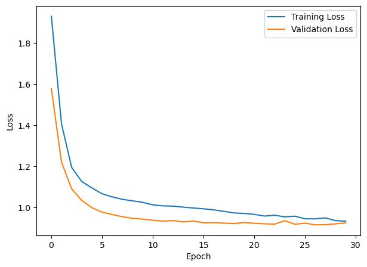

```python
# Visualize the training and validation loss for ModelA1
plt.figure(figsize=(7,5))
plt.plot(historyA1.history['loss'], label='Training Loss')
plt.plot(historyA1.history['val_loss'], label='Validation Loss')
plt.xlabel('Epoch')
plt.ylabel('Loss')
plt.legend()
plt.show()

# PlotLossAccuracy(historyA1, 'ModelA1(Basic)')
```

### Q.3.C.ii. Training Accuracy and Validation Accuracy

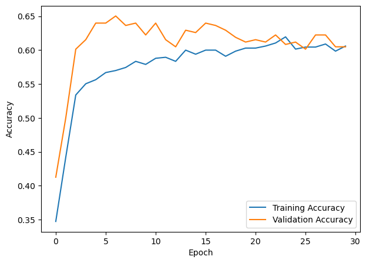

```python
# prompt: plot visual for : Training Accuracy and Validation Accuracy for ModelA1

# Visualize the training and validation accuracy
plt.figure(figsize=(7,5))
plt.plot(historyA1.history['accuracy'], label='Training Accuracy')
plt.plot(historyA1.history['val_accuracy'], label='Validation Accuracy')
plt.xlabel('Epoch')
plt.ylabel('Accuracy')
plt.legend()
plt.show()

# PlotLossAccuracy(historyA1, 'ModelA1(Basic)')
```

**Obervations**

Loss is decresing and accuracy is increasing. Shows that model is learning.

Training and validation accuracy seems to be inline for this model and both are showing average results.

Validation accuracy is slightly better than training accuracy.

Validation loss is consisitently slightly lesser that training loss.